# Correlation (The Math Sorcerer)

Luis Cárceles

2024-04-05

See The [YouTube play list](https://www.youtube.com/playlist?list=PLO1y6V1SXjjMelPvG5nKrqUt2aPr84Ryx) by the Math Sorcerer

## Introduction

Correlation coefficient estimation (Pearson):

$$\hat{\rho}=R=\frac{S_{xy}}{\sqrt{S_{xx}S_{yy}}}$$

Where: $S_{xx}=\sum_{i=1}^n(x_i-\bar{x})^2$, $S_{yy}=\sum_{i=1}^n(y_i-\bar{y})^2$ y $S_{xy}=\sum_{i=1}^n(x_i-\bar{x})(y_i-\bar{y})$.

### Hypothesis test for correlation coefficient

For the hypothesis test about the correlation we use the statistic:

$$T_{n-2}=\frac{R\sqrt{n-2}}{\sqrt{1-R^2}}$$

Where $R$ is the estimated correlation coefficient, obtained with the above formula and $n$ is the number of points. The distribution of $T_{n-2}$ is Student T with $n-2$ degrees of freedom.

## Problems

### Problem 1

Use the given data set to complete parts (a) through (C). (Use $\alpha=0.05$)

x: 10, 8, 13, 9, 11, 14, 6, 4, 12, 7, 5

Y: 9.13, 8.15, 8.73, 8.77, 9.27, 8.11, 6.14, 3.09, 9.14, 7.26, 4.75

Solution

1. Plot the y versus x scatterplot:

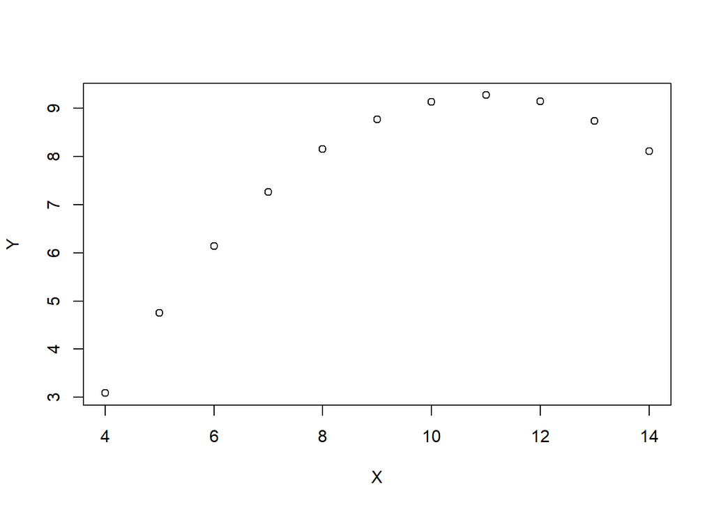

```r
X<-c(10, 8, 13, 9, 11, 14, 6, 4, 12, 7, 5)
Y<-c(9.13, 8.15, 8.73, 8.77, 9.27, 8.11, 6.14, 3.09, 9.14, 7.26, 4.75)
plot(X,Y)
```

2. Compute the linear correlation coefficient:

```r
Sxx<-sum((X-mean(X))^2)
Syy<-sum((Y-mean(Y))^2)
Sxy<-sum((X-mean(X))*(Y-mean(Y)))
R<-Sxy/sqrt(Sxx*Syy)
n<-length(X)
sprintf("The linear correlation coefficient is: %f", R)
```

```
## [1] "The linear correlation coefficient is: 0.816126"
```

The correlation can also be calculated using the built-in function cor():

```r
sprintf("Using the R built-in fuction: %f", cor(X,Y))
```

```
## [1] "Using the R built-in fuction: 0.816126"
```

Determine whether there is sufficient evidence to support the claim of a linear correlation between the two variables:

Hypothesis Test:

- $H_{0}$: $\rho=0$
- $H_{1}$: $\rho\ne0$

Computing the statistic:

```r
t<-R*sqrt(n-2)/sqrt(1-R^2)
sprintf("The statistic value is: %f", t)
```

```
## [1] "The statistic value is: 4.236879"
```

For this statistic, the p-value is:

```r
p_value<-2*pt(q = t, df = n-2 , lower.tail = FALSE)
sprintf("The p-value for the estatistic t is : %f", p_value)
```

```
## [1] "The p-value for the estatistic t is : 0.002184"
```

At, for example, 1% significance level, the hypothesis $H_{0}$ must be rejected. This means that there is sufficient evidence to support the alternative hypothesis and we can say that the values X and Y are correlated. Remember that we are talking about a *linear* relationship.

Construct the 95% confidence interval for R:

```r
alpha<-1-0.95
z<-qnorm(alpha/2, 0, 1, lower.tail=FALSE)
lowLimit<-((1+R)-(1-R)*exp(2*z/sqrt(n-3)))/((1+R)+(1-R)*exp(2*z/sqrt(n-3)))
highLimit<-((1+R)-(1-R)*exp(-2*z/sqrt(n-3)))/((1+R)+(1-R)*exp(-2*z/sqrt(n-3)))
sprintf("The lower limit of the confidence interval is: %f", lowLimit)
```

```
## [1] "The lower limit of the confidence interval is: 0.423668"
```

```r
sprintf("The upper linut if the confidence interval is: %f", highLimit)
```

```
## [1] "The upper linut if the confidence interval is: 0.950608"
```

All we have don so far can be done with the built-in function cor.test():

```r
cor.test(X,Y)
```

```
##
##  Pearson's product-moment correlation
##
## data:  X and Y
## t = 4.2369, df = 9, p-value = 0.002184
## alternative hypothesis: true correlation is not equal to 0
## 95 percent confidence interval:
##  0.4236685 0.9506084
## sample estimates:
##       cor
## 0.8161265
```

To explore the attributes of this new function:

```r
attributes(cor.test(X,Y))
```

```
## $names
## [1] "statistic"   "parameter"   "p.value"     "estimate"    "null.value"
## [6] "alternative" "method"      "data.name"   "conf.int"
##
## $class
## [1] "htest"
```

### Problem 2

Use the given data set to complete parts (a) through (C). (Use $\alpha=0.05$)

x: 10, 8, 13, 9, 11, 14, 6, 4, 12, 7, 5

Y: 7.45, 6.77, 12.73, 7.11, 7.82, 8.84, 6.07, 5.39, 8.14, 6.41, 5.73

Solution:

1. Construct a scatterplot.

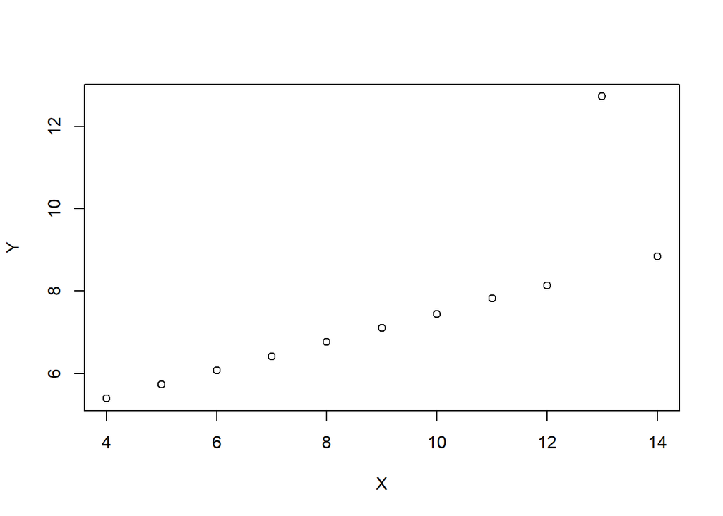

```r
X<-c(10, 8, 13, 9, 11, 14, 6, 4, 12, 7, 5)
Y<-c(7.45, 6.77, 12.73, 7.11, 7.82, 8.84, 6.07, 5.39, 8.14, 6.41, 5.73)
plot(X,Y)
```

(b): Compute the linear correlation coefficient: In this case se just use the R built-in function cor().

```r
R<-cor(X,Y)
sprintf("The linear correlation coefficient is: %f", R)
```

```
## [1] "The linear correlation coefficient is: 0.816736"
```

(c): Determine whether there is sufficient evidence to support the claim of a linear correlation between the two variables.

```r
cortest<-cor.test(X,Y)
sprintf("The linear correlation coefficient is: %f", cortest$estimate)
```

```
## [1] "The linear correlation coefficient is: 0.816736"
```

```r
sprintf("The value of the statistic in the test is: %f", cortest$statistic)
```

```
## [1] "The value of the statistic in the test is: 4.246380"
```

```r
sprintf("The p-value of that statistic in the test is: %f", cortest$p.value)
```

```
## [1] "The p-value of that statistic in the test is: 0.002154"
```

As in problem 1, we must reject $H_{0}$ and admit that there is sufficient evidence to support the alternative hypothesis which is that the two variables are linear correlated.

the 95% confidence interval is:

```r
sprintf("The lower limit of the confidence interval is: %f", cortest$conf.int[1])
```

```
## [1] "The lower limit of the confidence interval is: 0.425168"
```

```r
sprintf("The upper linut if the confidence interval is: %f", cortest$conf.int[2])
```

```
## [1] "The upper linut if the confidence interval is: 0.950784"
```